# Quantile modelling of UK electricity demand: solution

Matteo Fasiolo

2019-09-20

1. Load data and fit a basic Gaussian GAM:

```r
library(mgcViz);
data("UKload")
form <- NetDemand~s(wM,k=20,bs='cr') + s(wM_s95,k=20,bs='cr') +
        s(Posan, k=50, bs = "cr") + Dow + s(Trend,k=4,bs='cr') +
        NetDemand.48 + Holy
```

2. Fit model and plot smooths

```r
qu <- 0.5
fit <- qgamV(form = form, data = UKload, qu = qu)
```

```
## Estimating learning rate. Each dot corresponds to a loss evaluation.
## qu = 0.5...............done
```

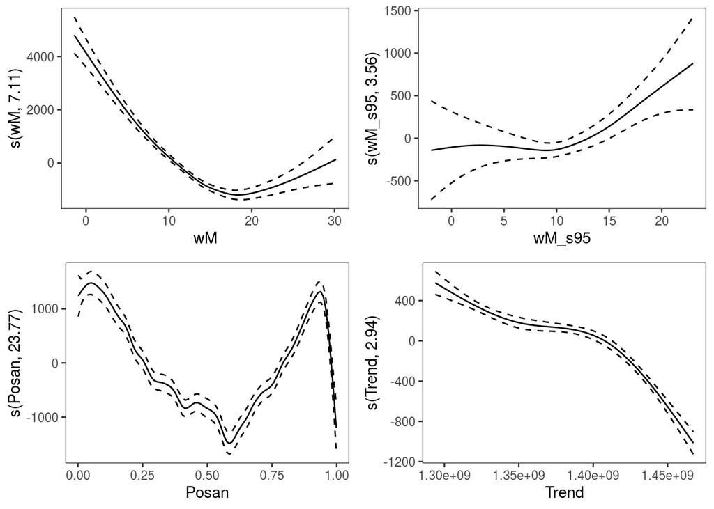

```r
print(plot(fit), pages = 1)
```

```r
summary(fit)
```

```
##
## Family: elf
## Link function: identity
##
## Formula:
## NetDemand ~ s(wM, k = 20, bs = "cr") + s(wM_s95, k = 20, bs = "cr") +
##     s(Posan, k = 50, bs = "cr") + Dow + s(Trend, k = 4, bs = "cr") +
##     NetDemand.48 + Holy
##
## Parametric coefficients:
##                Estimate Std. Error z value Pr(>|z|)
## (Intercept)  20887.2945   544.3989   38.37   <2e-16 ***
## Dowjeudi      3594.1411    97.2095   36.97   <2e-16 ***
## Dowlundi      6151.3226    61.0488  100.76   <2e-16 ***
## Dowmardi      3641.4409   100.9306   36.08   <2e-16 ***
## Dowmercredi   3702.1563    96.1229   38.52   <2e-16 ***
## Dowsamedi    -1671.7618    93.9515  -17.79   <2e-16 ***
## Dowvendredi   3325.9847    96.5900   34.43   <2e-16 ***
## NetDemand.48     0.4236     0.0146   29.00   <2e-16 ***
## Holy1        -3629.1102   301.4019  -12.04   <2e-16 ***
## ---
## Signif. codes:  0 '***' 0.001 '**' 0.01 '*' 0.05 '.' 0.1 ' ' 1
##
## Approximate significance of smooth terms:
##              edf Ref.df Chi.sq p-value
## s(wM)      7.114  8.734 339.98 < 2e-16 ***
## s(wM_s95)  3.564  4.720  18.46 0.00193 **
## s(Posan)  23.765 29.109 473.33 < 2e-16 ***
## s(Trend)   2.937  2.996 434.61 < 2e-16 ***
## ---
## Signif. codes:  0 '***' 0.001 '**' 0.01 '*' 0.05 '.' 0.1 ' ' 1
##
## R-sq.(adj) =  0.946   Deviance explained = 86.1%
## -REML =  16280  Scale est. = 1         n = 2008
```

The effect of `Posan` is fairly wiggly and drops sharply in the Christmas period.

3. Modify model formula and refit

```r
form <- NetDemand~s(wM,k=20,bs='cr') + s(wM_s95,k=20,bs='cr') +
        s(Posan, bs='ad', k=50) + Dow + s(Trend,k=4) +
        NetDemand.48 + Holy

fit <- qgamV(form = form, data = UKload, qu = qu)
```

```
## Estimating learning rate. Each dot corresponds to a loss evaluation.
## qu = 0.5...............done
```

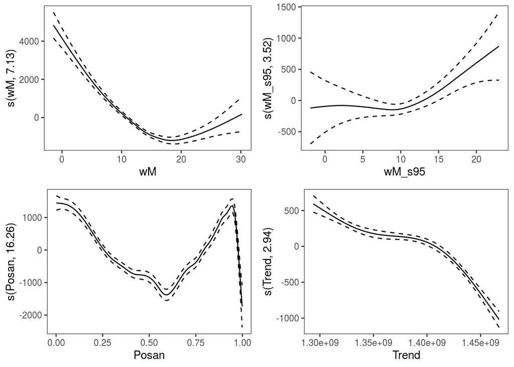

```r
print(plot(fit), pages = 1)
```

```r
summary(fit)
```

```
##
## Family: elf
## Link function: identity
##
## Formula:
## NetDemand ~ s(wM, k = 20, bs = "cr") + s(wM_s95, k = 20, bs = "cr") +
##     s(Posan, bs = "ad", k = 50) + Dow + s(Trend, k = 4) + NetDemand.48 +
##     Holy
##
## Parametric coefficients:
##                Estimate Std. Error z value Pr(>|z|)
## (Intercept)   2.086e+04  5.481e+02   38.05   <2e-16 ***
## Dowjeudi      3.590e+03  9.837e+01   36.49   <2e-16 ***
## Dowlundi      6.152e+03  6.102e+01  100.82   <2e-16 ***
## Dowmardi      3.648e+03  1.015e+02   35.93   <2e-16 ***
## Dowmercredi   3.701e+03  9.794e+01   37.78   <2e-16 ***
## Dowsamedi    -1.676e+03  9.462e+01  -17.71   <2e-16 ***
## Dowvendredi   3.321e+03  9.761e+01   34.02   <2e-16 ***
## NetDemand.48  4.243e-01  1.471e-02   28.85   <2e-16 ***
## Holy1        -3.457e+03  3.003e+02  -11.51   <2e-16 ***
## ---
## Signif. codes:  0 '***' 0.001 '**' 0.01 '*' 0.05 '.' 0.1 ' ' 1
##
## Approximate significance of smooth terms:
##              edf Ref.df Chi.sq p-value
## s(wM)      7.133  8.762 343.70 < 2e-16 ***
## s(wM_s95)  3.524  4.669  18.27 0.00201 **
## s(Posan)  16.259 19.634 478.24 < 2e-16 ***
## s(Trend)   2.940  2.997 431.87 < 2e-16 ***
## ---
## Signif. codes:  0 '***' 0.001 '**' 0.01 '*' 0.05 '.' 0.1 ' ' 1
##
## R-sq.(adj) =  0.946   Deviance explained = 86.5%
## -REML =  16271  Scale est. = 1         n = 2008
```

Now the effect of `Posan` is smoother along most of the year, but it drops around Christmas even more than before. This is because many businesses are shut and people go on holiday during this period. An adaptive basis makes so that we use lots of degrees of freedom where they are needed (winter holiday) and few where the effect is smooth. Alternatively, we could have added a factor for the winter period (although one might point out that we have already included a dummy variable indicating bank holidays).

4. mqgam fit and plotting effects for each quantile

```r
nqu <- 5
qus <- seq(0.1, 0.9, length.out = nqu)
fitM <- mqgamV(form = form, data = UKload, qu = qus)
```

```
## Estimating learning rate. Each dot corresponds to a loss evaluation.
## qu = 0.5...............done
## qu = 0.3...........done
## qu = 0.7...........done
## qu = 0.1........................done
## qu = 0.9......................done
```

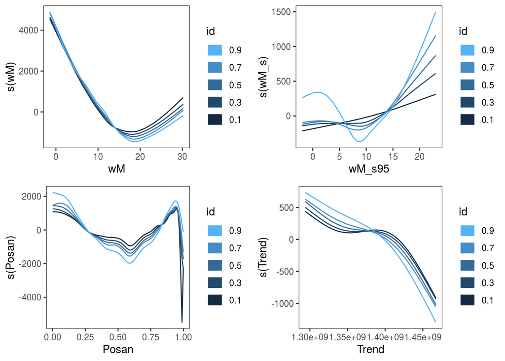

```r
print(plot(fitM), pages = 1)
```

Notice that when the effects of low and high quantiles diverge, the conditional variance of the response is increasing (other things being equal). Along `wM_s95` we can also see that at low temperatures the load distribution is skewed to the right (again, other things being equal). Looking at the plot for `Posan`, look at how the Christmas effect changes depending on the quantile. The lowest quantiles, are more strongly effected: they go down and then bounce back. We couldn’t get such insights with a Gaussian GAM!

We can also look at the parametric effects:

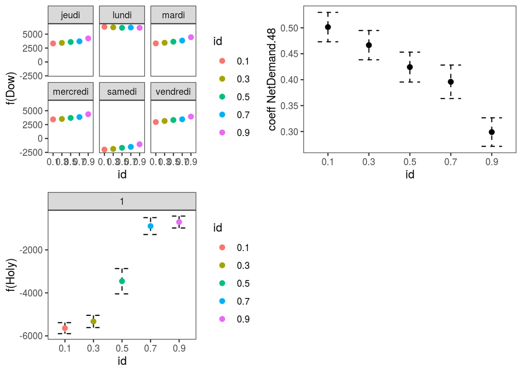

```r
print(plot(fitM, allTerms = T, select = 5:7), pages = 1)
```

It is interesting to notice that the holiday effect is stronger (more negative) on the low quantiles.

5. Model checking

We can verify whether the fraction of points falling below the fit depart too much from $\tau = 0.5$, along each covariate:

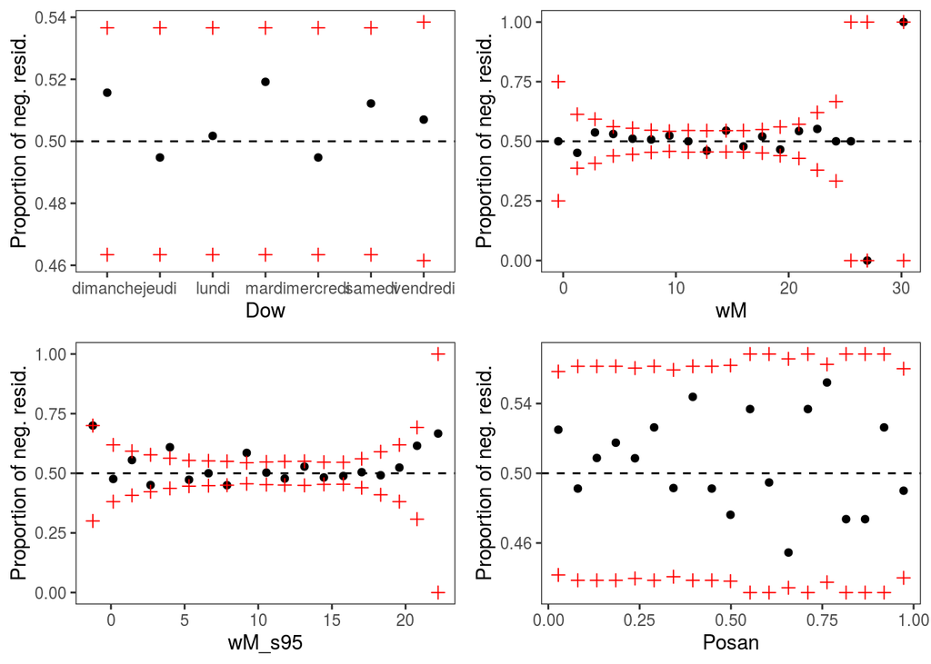

```r
pl <- check1D(fitM[[3]], x = list("Dow", "wM", "wM_s95", "Posan")) + l_gridQCheck1D(qu = qus[3])
print(pl, pages = 1)
```

Looks good, most departures are within 80 percent confidence bands.